SCAN's Amazon Primates' Chorotypes

Ct = 0.8 - 'threshold' muito restritivo - chorotypes com espécies com alta similaridade espacial

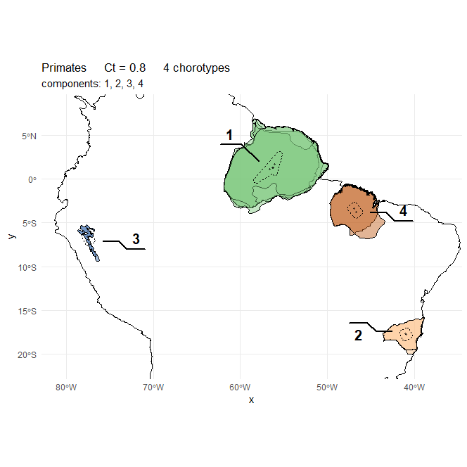

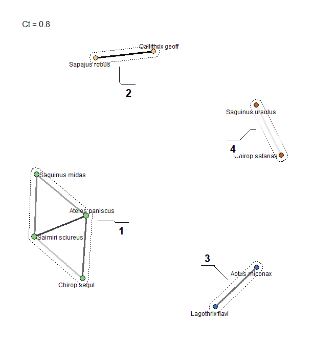

Ct = 0.75

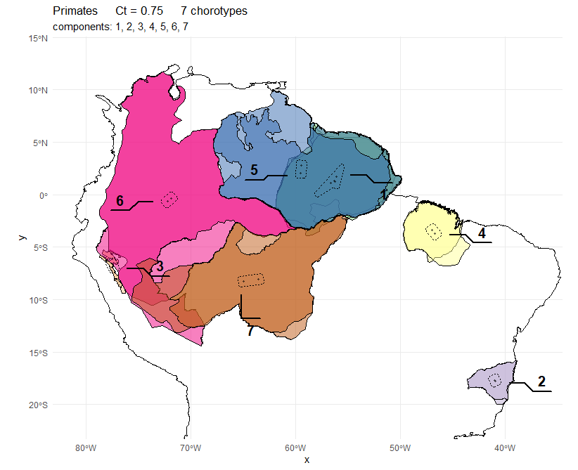

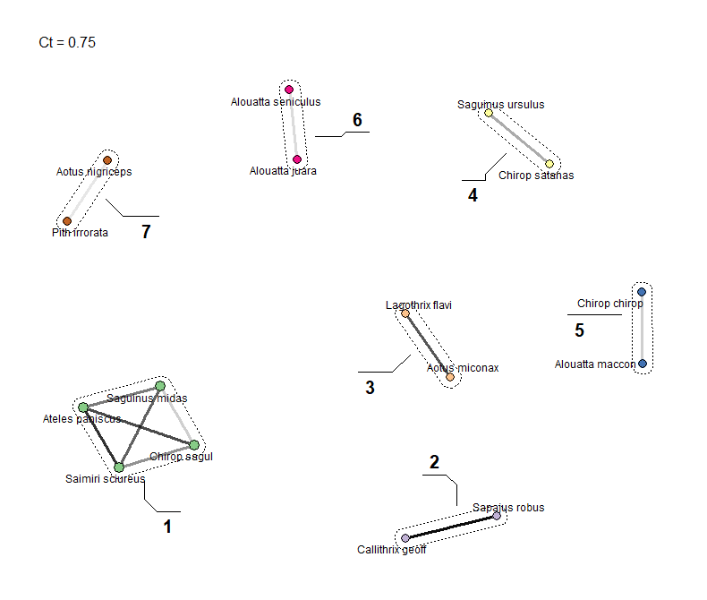

Ct = 0.7

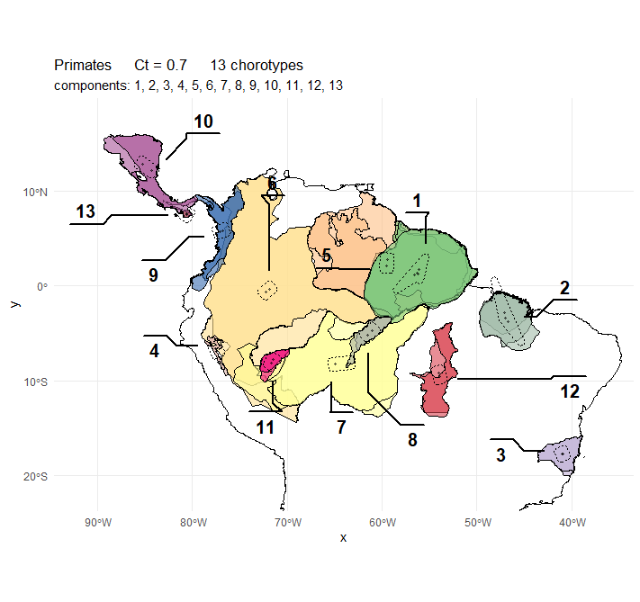

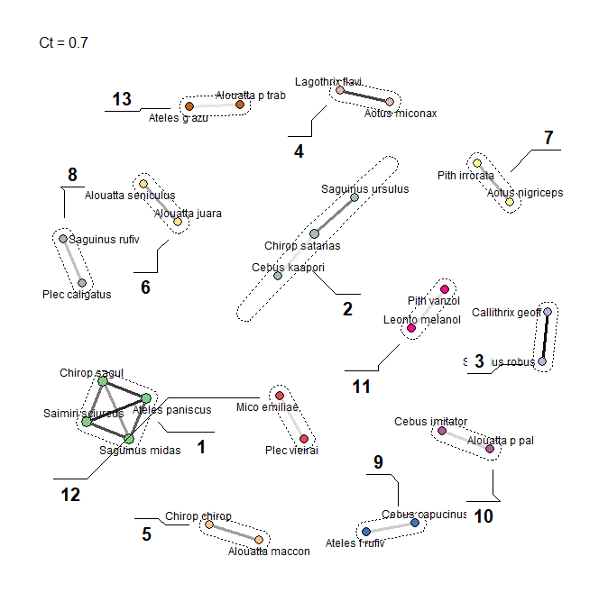

Ct = 0.6

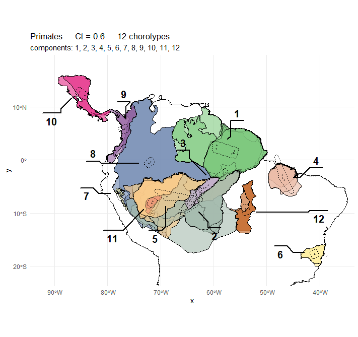

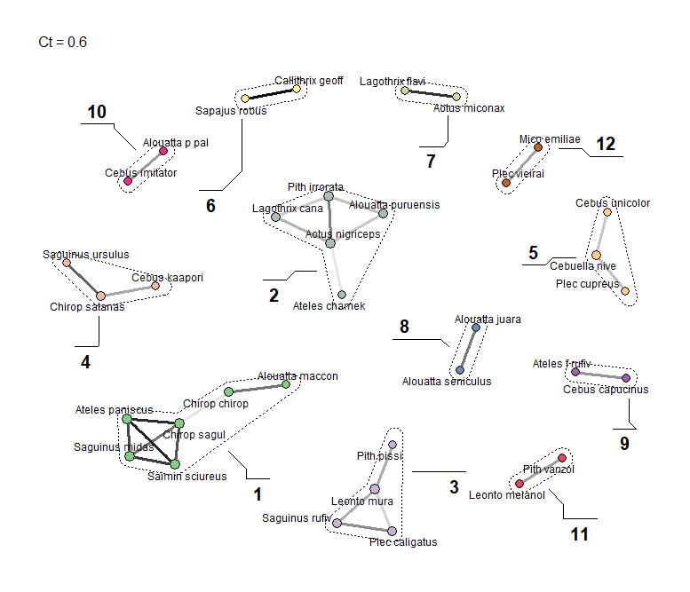

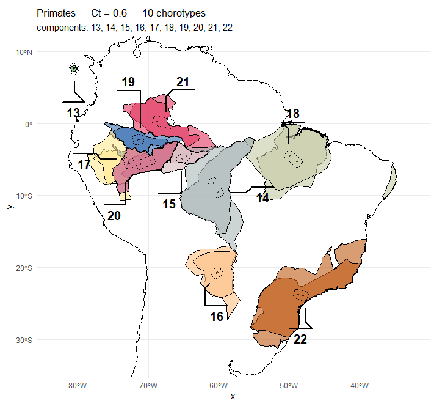

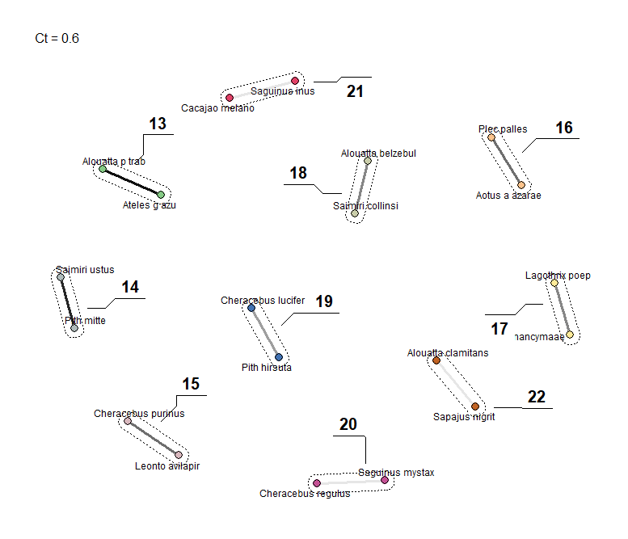

Ct = 0.5

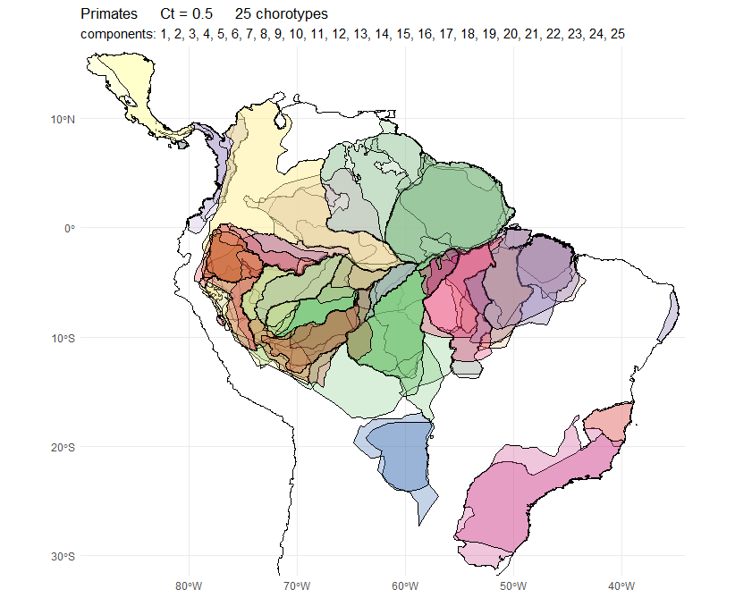

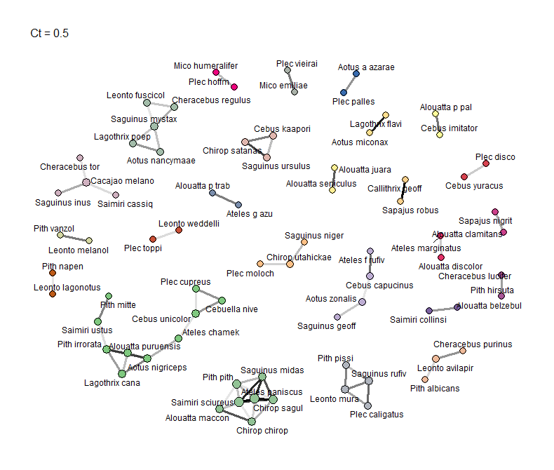

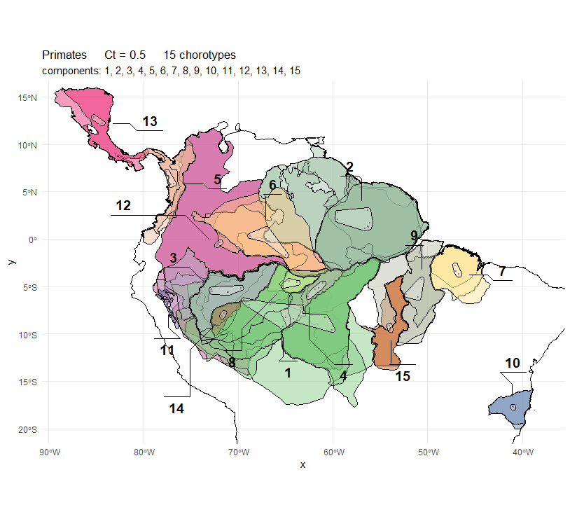

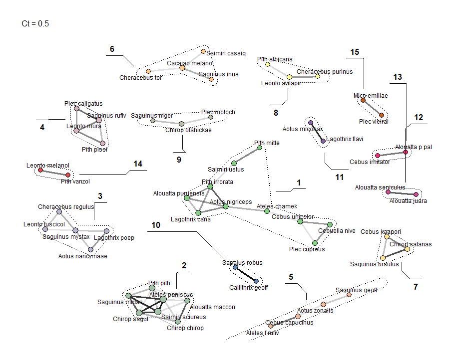

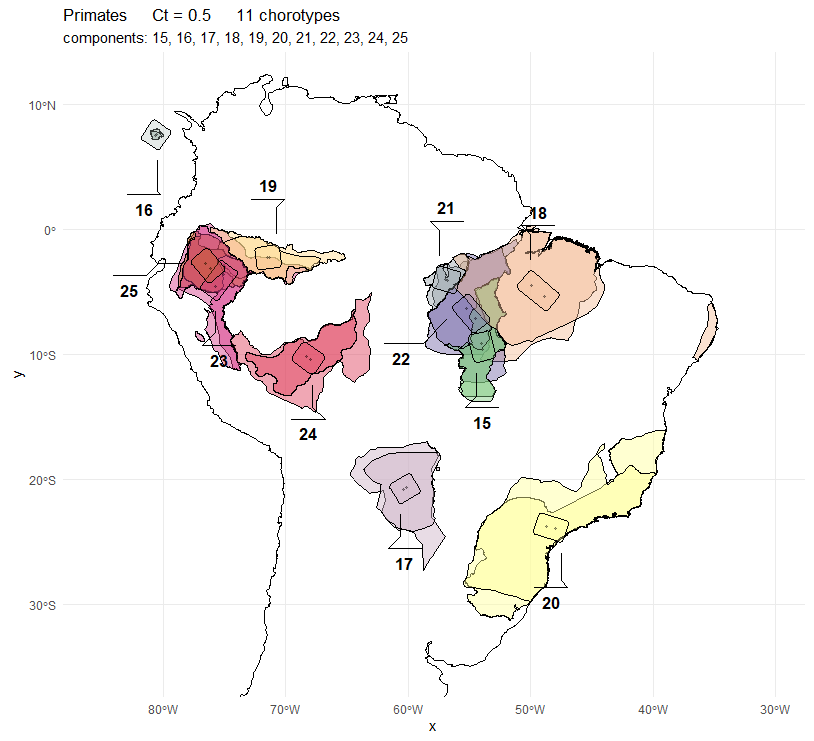

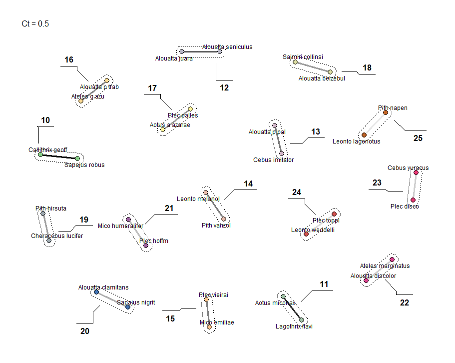

Ct = 0.4

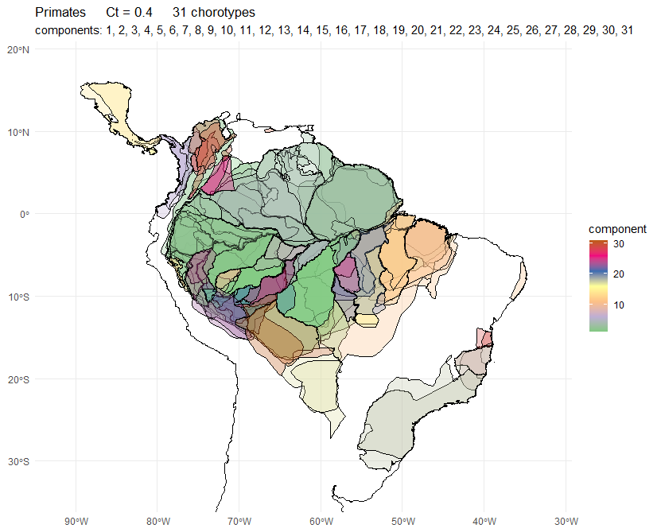

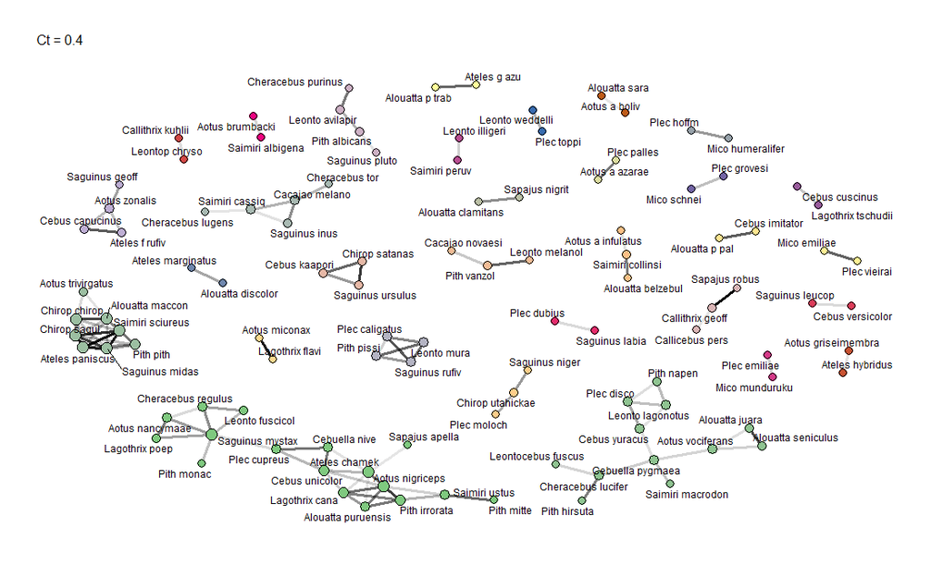

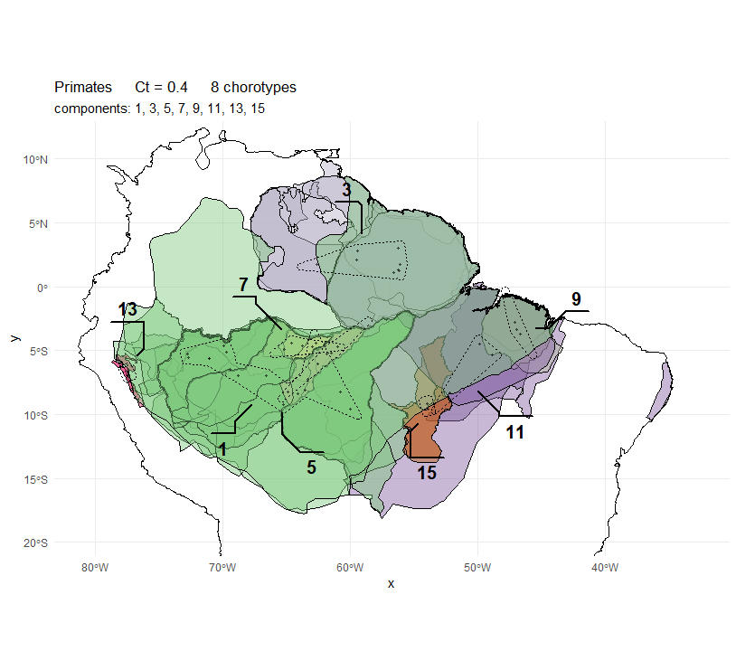

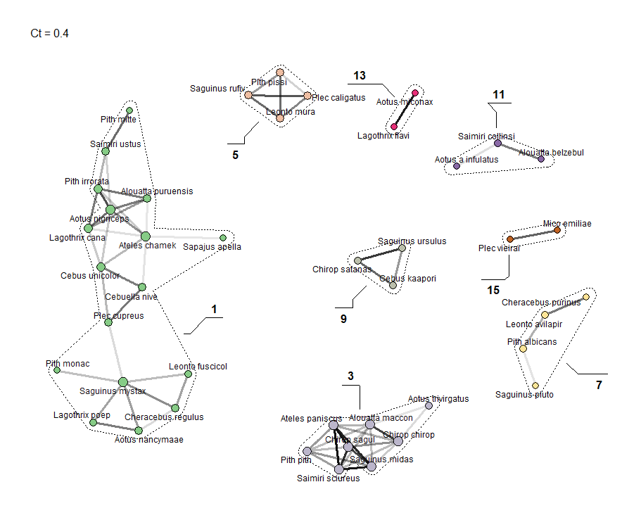

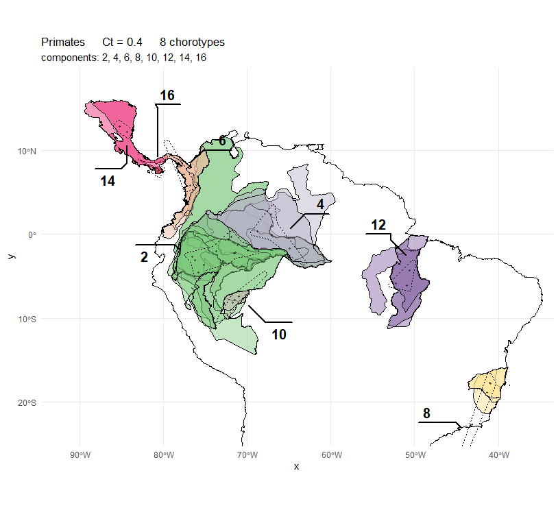

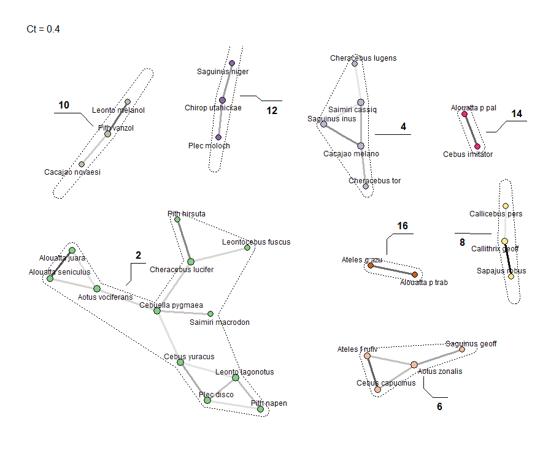

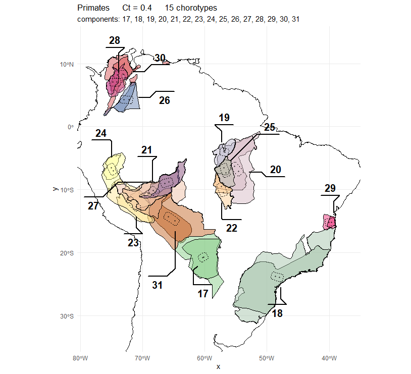

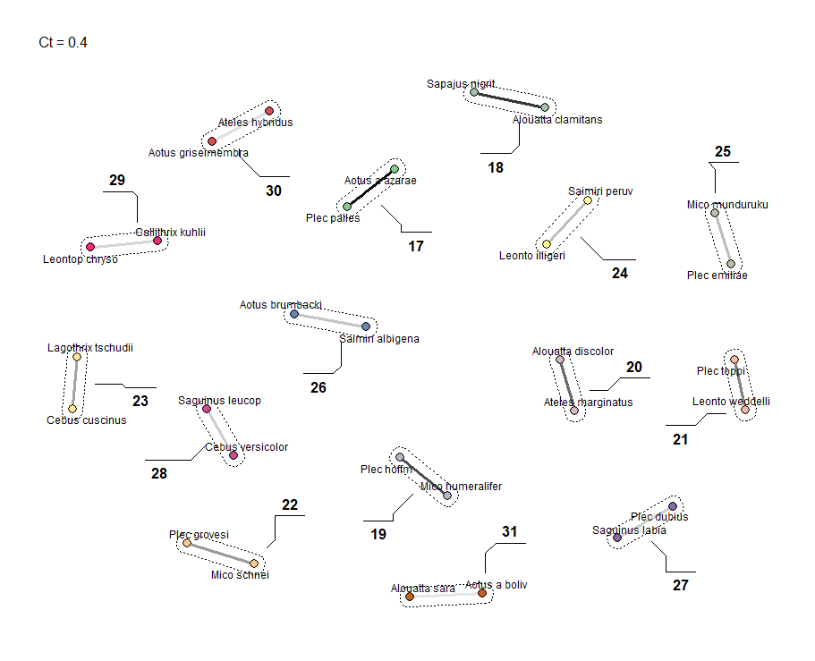

Scripts for Graphs and Maps

library(extrafont)  
loadfonts(device = "win")  
library(ggplot2)  
library(ggforce)  
# customizing maps  
# SA & rivers  
sa = st_read("C:/SIG2018/south_america_clean_shape/south_america_clean_shape.shp")  
sa = sa %>% st_transform(crs = st_crs(shp))  
shp_sa = rbind(shp,sa %>% select(sp = group))  
rivers = st_read("C:/SIG2018/Rivers/majorrivers_0_0/majorrivers.shp")  
rivers = rivers %>% select(sp = NAME) %>% st_filter(sa)  
amazon_rivers = rivers %>% group_by() %>% summarise() %>% mutate(sp = 'rivers') %>% select(sp, geometry)  
shp_sa = rbind(shp_sa, amazon_rivers)  
#### PRIMATES ####  
##### SCAN ANALYSIS 0.94 TO 0.2 NO FILTERS ###################################################################################  
# last MOD SCAN_lite with mark_overlap and filer_overlap distinction  
bs11111 = SCAN_lite(max_Ct = 0.94, Ct_resolution = -0.01, min_Ct = 0.2, max_diameter = 20, mark_overlap =TRUE)  
tab = bs11111$chorotypes %>% mutate(fst = first(chorotype_spp %>% strsplit(., split = ',') %>% first())) %>%  
arrange(fst, diameter, desc(Ct_max)) %>% select(-'fst')  
# save table  
tab %>% write.csv2("Primate_chorotypes_SA_94-20_no_filter_1.csv")  
chor = tab  
#  
##### GRAPH & MAP PLOTS ######  
# plot graphs and maps with the same palette color (it took a whole day to figure out how to do this...)  
# find species and components in graph  
g = bs11111$graph  
#### SET THRESHOLD & SUBSET GRAPH ####  
threshold = 0.5  
g_full = g %>% activate(nodes) %>% #as_tibble %>%  
filter(get(paste0("Ct",threshold))) %>%  
select(name, paste0('components',threshold)) %>%  
activate(edges) %>% select(from, to, Cs, paste0('Ct',threshold)) %>%  
filter(get(paste0("Ct",threshold))) %>%  
activate(nodes) %>% arrange(get(paste0('components',threshold)), name)  
# total components (chorotypes)  
print('all_components'); g_full %>% activate(nodes) %>% select(contains('components')) %>% pull() %>% unique()  
# SETUP  
{save = FALSE; part = 1; cut = 9; select_chorotypes = TRUE;  
device1 = 4; device2 = 5  
palette = "Accent"#'Greens'#"Spectral" # "Reds"# "Spectral",  
list_chorotypes = seq(1,31); #seq(17,31,1) #seq(2, 16, 2) #seq(1,15, by = 2)# c(15:25) ;# c(1:15)  
}  
# partial g_sub  
if(isTRUE(select_chorotypes)){ g_sub = g_full %>% activate(nodes) %>% filter(get(paste0('components', threshold)) %in% list_chorotypes); ind = ''  
} else {if(part == 1) {g_sub = g_full %>% activate(nodes) %>% filter(get(paste0('components', threshold)) < cut); ind = 'A'  
} else {g_sub = g_full %>% activate(nodes) %>% filter(get(paste0('components', threshold)) >= cut); ind = 'B'}}  
{n_comp = g_sub %>% activate(nodes) %>% select(contains('components')) %>% pull() %>% unique() %>% length()  
comps = g_sub %>% activate(nodes) %>% select(contains('components')) %>% pull() %>% unique() %>% paste0(.,collapse = ", ")  
print('components')  
print(comps)}  
# get species to the map  
{g_spp = g_sub %>% activate(nodes) %>% as_tibble()  
# right join to preserve sf attributes in tibble (the left object is spatial - the result inherits its properties)  
g_map1 = right_join( map, g_spp, by = c('sp' = 'name')) %>%  
select(component = paste0('components',threshold), everything())  
} # not merging sa map to species shapes to plot separately  
# use_sa = FALSE; if(isTRUE(use_sa)){g_map2 = rbind(map %>% filter(sp =='sa') %>% mutate(component = 0) %>% select( component, sp, geometry), g_map)}  
# CHECK both map and graph species and components  
g_map1 %>% st_drop_geometry() %>% group_by(component) %>% summarise(spp = paste0(sp, collapse = ', '))  
g_sub %>% activate(nodes) %>% select(name, comp = paste0('components', threshold)) %>% as_tibble() %>%  
group_by(comp) %>% summarise(spp = paste(name, collapse = ', '))  
# PLOTs  
# graph setups  
{deg <- degree(g_sub, mode="all")  
lay = create_layout(g_sub, layout = 'fr')# 'graphot') # 'fr') # 'dh') # 'mds')#"drl") # other options kk, fr, ldl, gem  
lou <- cluster_louvain(g_sub)  
label = FALSE}  
dev.set(device1)  
# fancy  
# assign(paste0('graph_Ct',threshold),  
basic_graph =  
ggraph(lay) +  
geom_edge_link(aes(alpha = (Cs+0.75)) , width = 1.25 , show.legend = FALSE) + #  
geom_node_point(aes(fill = ifelse(!is.na(get(paste0("components",threshold))),as.factor(get(paste0("components",threshold))), NA)),  
size = (degree(g_sub, mode="all") + 12) / 4, shape = 21, show.legend = FALSE) +  
scale_fill_distiller( direction = 1, palette = palette, #"Spectral",  
na.value = "transparent", aesthetics = "fill") + #"BrBG" , #RdYlGn","PiYG",  
geom_node_text(aes(label = name), size = 3, col = "black", repel=TRUE) +  
labs( subtitle = paste0("Ct = ", threshold)) +  
theme_graph()  
# add hull and community labels  
basic_graph2 = basic_graph +  
geom_mark_hull(aes(x, y, group = get(paste0("components",threshold))  
,label = get(paste0("components",threshold))),  
label.fontsize = 15,  
fill = "transparent", lty = "dotted",  
concavity = 1,  
expand = unit(3, "mm"),  
alpha = 0.05) +  
theme(legend.position = "none")  
basic_graph2  
if(isTRUE(save)) ggsave(paste0("Graph_Ct", threshold,"_",ind,".png"))  
##  
# graph_Ct = get(paste0('graph_Ct',threshold))  
# graph_Ct + facet_nodes(~ as.factor(get(paste0("components",threshold))))  
# + facet_nodes(~class)  
# simple  
# ggraph(lay) + geom_edge_link() + geom_node_point() + # size = 5, shape = 21, color = 'black') +  
# geom_node_text(aes(label = name)) + #, size = 4.5, repel=TRUE) +  
# theme_graph()  
# centroids as x,y aesthetics to hull  
g_map1 = g_map1 %>% mutate(centroids = st_centroid(geometry), x = st_coordinates(centroids)[,1],  
y = st_coordinates(centroids)[,2])  
dev.set(device2)  
alfa_map = 0.4  
basic_only = FALSE  
# Sophisticated maps  
if(isTRUE(basic_only)){  
basic_map =  
ggplot(data = g_map1 %>% arrange(component)) +  
geom_sf( aes(fill = component), # THIS IFELSE STAT. TURNS FILL TO CONTINUOUS... use distiller, otherwise scale_fill_brewer to discrete palette  
alpha = alfa_map, color = 'black', show.legend = F) +  
geom_sf(data = sa, fill = NA, color = 'black') +  
scale_fill_distiller( direction = 1, palette = palette, #"Spectral", #"BrBG" , #RdYlGn","PiYG", #scale_fill_continuous( na.value = "transparent") + # low = 'black', high = 'green',  
na.value = "transparent", aesthetics = "fill") + #start = 0.2, end = 0.8, #Diverging BrBG, PiYG, PRGn, PuOr, RdBu, RdGy, RdYlBu, RdYlGn, Spectral  
ggtitle(paste0("Primates Ct = ", threshold, " ", n_comp, " chorotypes"),  
sub = paste('components:', comps)) +# pull() %>% unique())) +  
theme_minimal()  
} else {  
basic_map2 =  
ggplot(data = g_map1 %>% arrange(component)) +  
geom_sf( aes(fill = as.numeric(component)), # if fill is factor use scale_fill_brewer which is discrete  
alpha = alfa_map, color = 'black', show.legend = F) +  
geom_sf(data = sa, fill = NA, color = 'black') +  
geom_point(aes(x,y), size = 0.7, alpha = 0.5) +  
geom_mark_hull(aes(x,y, group = component, label = component), #col = "transparent",  
expand = unit(2, "mm"), radius = unit(1, "mm"),alpha = 0.5,  
label.fill = "transparent", lty = 'dotted',  
con.size = 1, label.fontsize = 15) +  
scale_fill_distiller( direction = 1, palette = palette, #"Spectral", #"BrBG" , #RdYlGn","PiYG", #scale_fill_continuous( na.value = "transparent") + # low = 'black', high = 'green',  
na.value = "transparent", aesthetics = "fill") + #start = 0.2, end = 0.8, #Diverging BrBG, PiYG, PRGn, PuOr, RdBu, RdGy, RdYlBu, RdYlGn, Spectral  
ggtitle(paste0("Primates Ct = ", threshold, " ", n_comp, " chorotypes"),  
sub = paste('components:', comps)) +# pull() %>% unique())) +  
theme_minimal() +  
theme(legend.position = "none")  
}  
# expand axes here according to this factor  
exp_fact = c(0.01,0.01)  
box = st_bbox(g_map1)  
# basic_map3 = basic_map2 + # scale_x_continuous(expand = exp_fact) +  
# scale_y_continuous(expand = exp_fact) +  
# coord_sf(xlim = c(range(g_map1$x)[1], range(g_map1$x)[2]) ,#-80,-50), # may use absolute limits  
# ylim = c(range(g_map1$y)[1], range(g_map1$y)[2])) #c(-20,20))  
# zoom based on bbox  
basic_map4 = basic_map2 +  
scale_x_continuous(expand = exp_fact) +  
scale_y_continuous(expand = exp_fact) +  
coord_sf(xlim = c(box[1], box[3]),  
ylim = c(box[2], box[4]))  
# zoom based on bbox No hulls  
basic_map5 = basic_map +  
scale_x_continuous(expand = exp_fact) +  
scale_y_continuous(expand = exp_fact) +  
coord_sf(xlim = c(box[1], box[3]),  
ylim = c(box[2], box[4]))  
basic_map5  
# assign(paste0('map_ct',threshold), basic_map3 )  
# print(get(paste0('map_ct',threshold)))  
if(isTRUE(save)) ggsave(paste0("Primates_map_",threshold,"_",ind,".png"))